# Health_Care

# We come to a conclusion that describe of mean, std,min,count,max

```python
healthcare_backup['Age'].mean()
```

```
37.08887421173107
```

# We come to a conclusion that describe the mean of Age

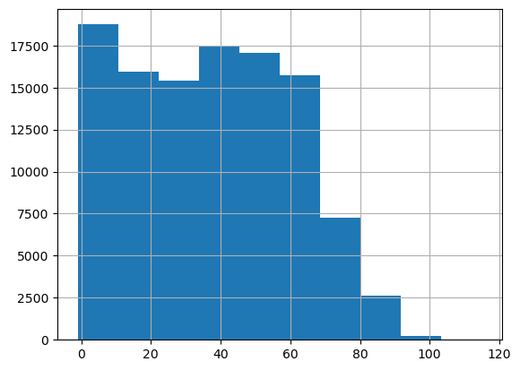

```python
healthcare_backup['Age'].hist()
```

# This is histogram plot of Age

```python
healthcare_backup['Gender'].value_counts()
```

```
F    71840
M    38687
Name: Gender, dtype: int64
```

# We come to a conclusion that total Number Male & Female

```python
# display the correlation matrix
healthcare_backup.corr()
```

|  | AppointmentID | Age | Scholarship | Hipertension | Diabetes | Alcoholism | Handcap | SMS_received |
| --- | --- | --- | --- | --- | --- | --- | --- | --- |
| AppointmentID | 1.000000 | -0.019126 | 0.022615 | 0.012752 | 0.022628 | 0.032944 | 0.014106 | -0.256618 |
| Age | -0.019126 | 1.000000 | -0.092457 | 0.504586 | 0.292391 | 0.095811 | 0.078033 | 0.012643 |
| Scholarship | 0.022615 | -0.092457 | 1.000000 | -0.019729 | -0.024894 | 0.035022 | -0.008586 | 0.001194 |
| Hipertension | 0.012752 | 0.504586 | -0.019729 | 1.000000 | 0.433086 | 0.087971 | 0.080083 | -0.006267 |
| Diabetes | 0.022628 | 0.292391 | -0.024894 | 0.433086 | 1.000000 | 0.018474 | 0.057530 | -0.014550 |
| Alcoholism | 0.032944 | 0.095811 | 0.035022 | 0.087971 | 0.018474 | 1.000000 | 0.004648 | -0.026147 |
| Handcap | 0.014106 | 0.078033 | -0.008586 | 0.080083 | 0.057530 | 0.004648 | 1.000000 | -0.024161 |
| SMS_received | -0.256618 | 0.012643 | 0.001194 | -0.006267 | -0.014550 | -0.026147 | -0.024161 | 1.000000 |

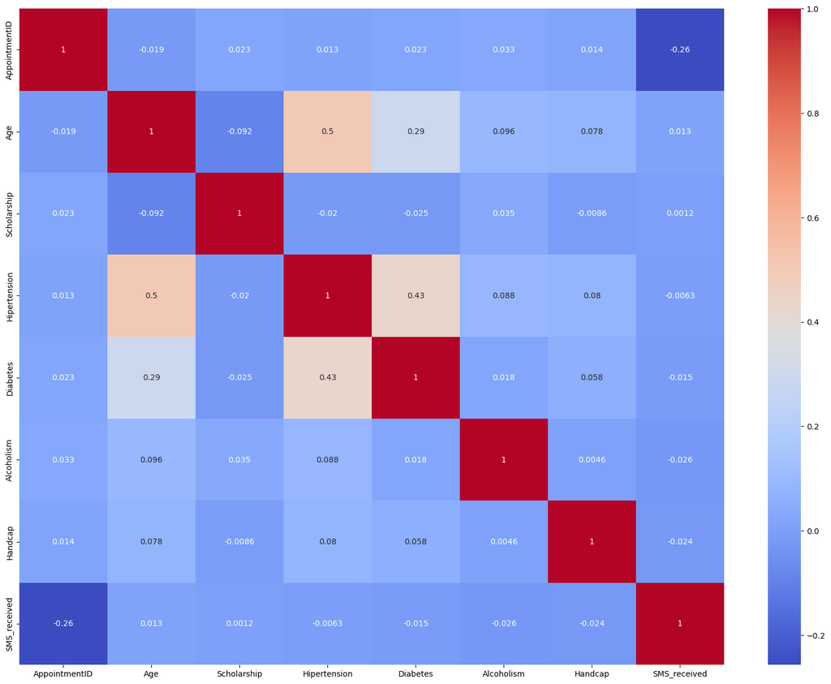

```python
corr = healthcare_backup.corr()
# plot the heat map
fig, ax = plt.subplots(figsize=(20,15))
sns.heatmap(corr, annot=True, ax=ax, cmap = 'coolwarm')
fig.savefig('Heat map of project.png')
```

# We come to a conclusion that this is corelation plot using heat map

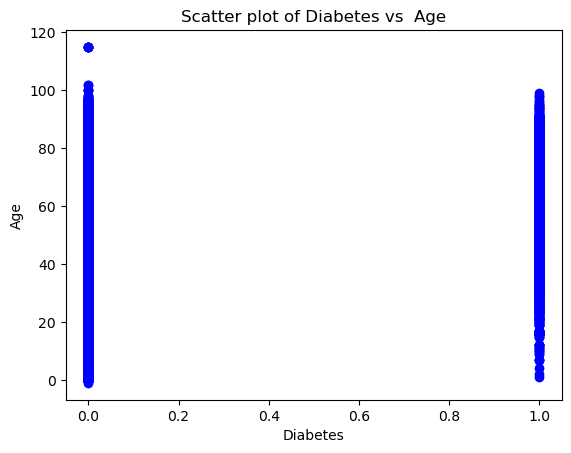

```python
import numpy as np
import matplotlib.pyplot as plt
plt.scatter(healthcare_backup['Diabetes'],healthcare_backup['Age'], c='blue')
plt.title('Scatter plot of Diabetes vs  Age')
plt.xlabel('Diabetes')
plt.ylabel('Age')
```

# We come to a conclusion that this is Scatter plot bet Age & Diabetes

# for the schedule day and appointment day storing the weekdays only into a variable

```python
# 5 is Saturday, 6 is Sunday

base_data['sch_weekday'] = base_data['ScheduledDay'].dt.dayofweek
```

```python
base_data['app_weekday'] = base_data['AppointmentDay'].dt.dayofweek
```

```python
base_data['sch_weekday'].value_counts()
```

```
1    26168
2    24262
0    23085
4    18915
3    18073
5       24
Name: sch_weekday, dtype: int64
```

# We come to a conclusion that there is no schedule day on sunday

```python
base_data['app_weekday'].value_counts()
```

```
2    25867
1    25640
0    22715
4    19019
3    17247
5       39
Name: app_weekday, dtype: int64
```

# We come to a conclusion that there is no appointment day on sunday

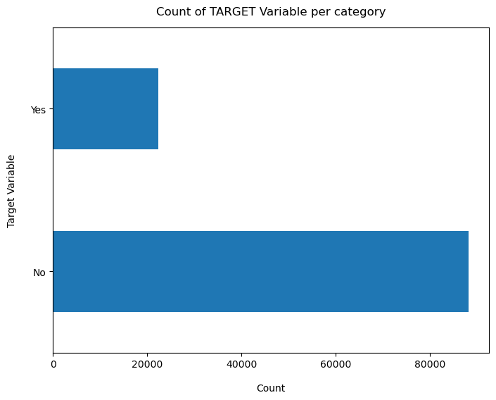

```python
base_data['NoShow'].value_counts().plot(kind='barh', figsize=(8, 6))
plt.xlabel("Count", labelpad=14)
plt.ylabel("Target Variable", labelpad=14)
plt.title("Count of TARGET Variable per category", y=1.02);
```

# We come to a conclusion that its show Target Variable

```python
# calculating the % of appointments or not
100*base_data['NoShow'].value_counts()/len(base_data['NoShow'])
```

```
No     79.806744
Yes    20.193256
Name: NoShow, dtype: float64
```

# We come to a conclusion that what % of appointment done

```python
base_data['NoShow'].value_counts()
```

```
No     88208
Yes    22319
Name: NoShow, dtype: int64
```